# Impact of Loan Features on Borrower Rate and Lender Yield

## by Flavian Kyande

## Investigation Overview

In this research, I wanted to find out loan features that impact the borrower rate and lender yield. The main features were income range, loan status and score rating.

## Dataset Overview

The dataset contained 113,937 personal loan records with 81 variables in each loan record which included the main features. I cleaned the data after finding outliers that had a massive impact on the data visualization.

## Distribution of Lender Yield and Borrower Rate

The LenderYield has a multi modal distribution. There are many peaks in the distribution. There is a huge spike around 0.31 meaning lenders yielded this rate more. BorrowerRate shares a similar distribution to LenderYield, a multimodal distribution with multiple peaks. The highest peak rate also appears around 0.32.

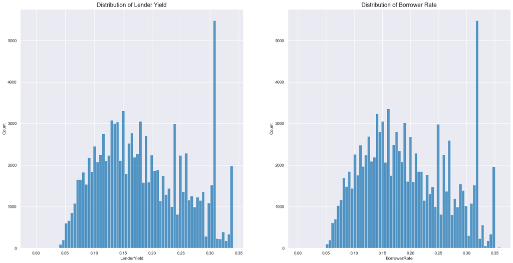

## Relationship between Borrow Rate and Lender Yield

There is a strong positive correlation between BorrowerRate and LenderYield. This means that as the borrower rate increases the lenders get a higher yield.

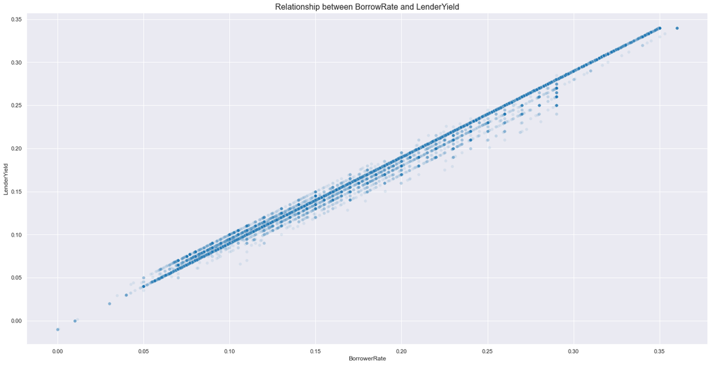

## Borrower Rate vs Lender Yield in the Two Main Feature Levels

There is a strong positive correlation in every level of the variables. As the BorrowerRate increases, the LenderYield also increases in each level. BorrowerRate is a good predictor of LenderYield and vice versa. The trend can be witnessed after plotting against two different levels. This signifies that both BorrowerRate and LenderYield are strongly and positively correlated.

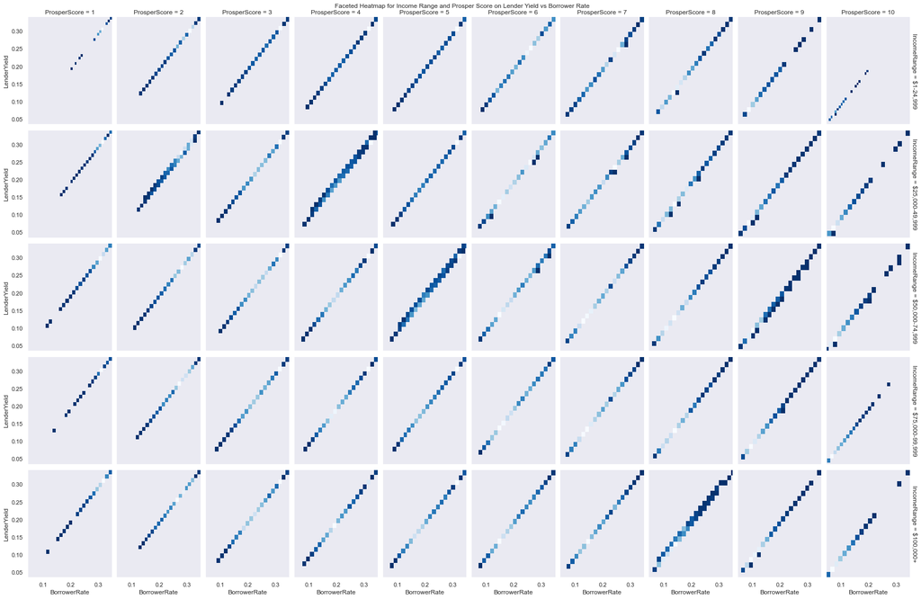